# Plotting with the graphics package, par(), and R colors

Feb 22, 2023

## Built-in Statistical Graphics

Common plot types, functions, and objectives

| Plot Type | R function | Objective |
| --- | --- | --- |
| Histogram | `hist()` | Statistical distributions |
| Boxplot | `boxplot()` | Statistical distributions |
| Barplot | `barplot()` | Categorical data |
| Scatterplot | `plot()` | Numerical data |
| Regression diagnostics | `plot()` | Assessing model fit |

## Histogram

- `rnorm()`
- `hist()`
- `density()`
- `lines()`

## Histogram

```r
?rnorm
```

```r
norm.dat<-rnorm(10000, 50, sd=10)
head(norm.dat)
```

```
## [1] 53.48286 53.73248 60.31454 53.06790 30.97580 64.40268
```

Usually takes a vector of numeric…

## Histogram

…but can also be a numeric matrix

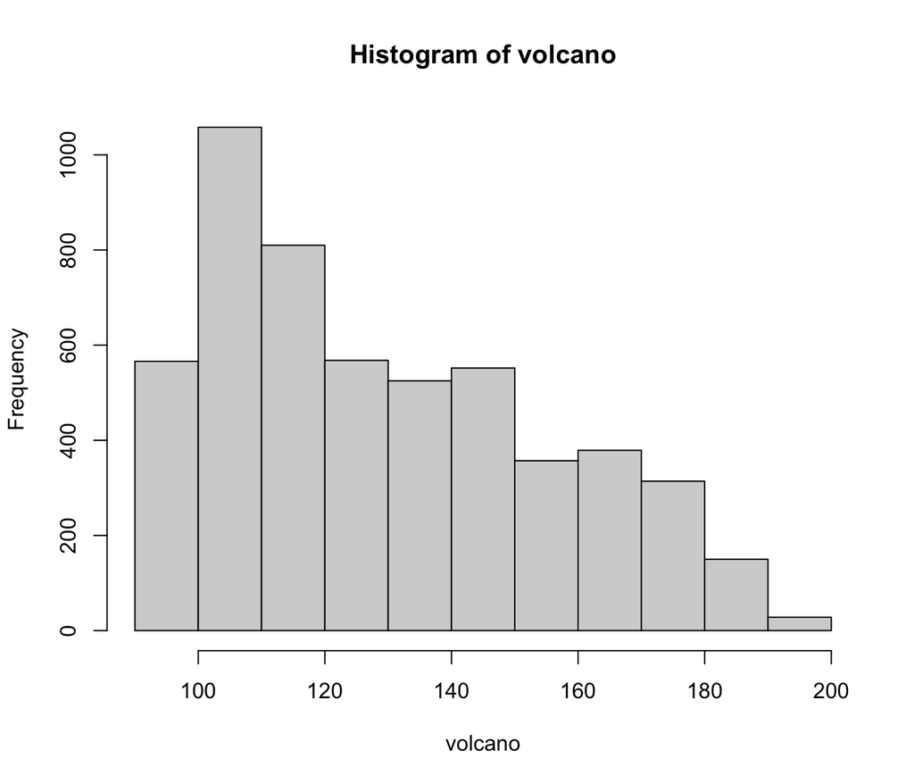

```r
data(volcano)
hist(volcano)
```

## Histogram

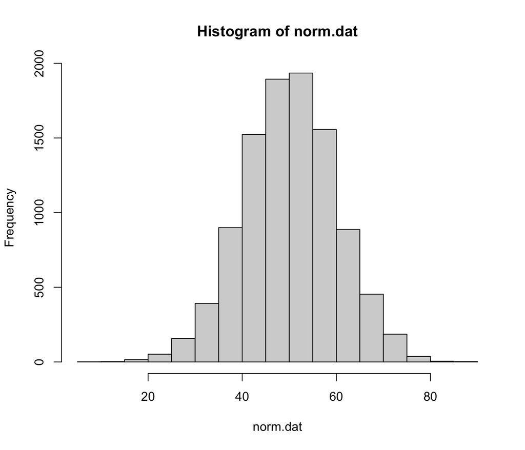

```r
hist(norm.dat)
```

## Histogram (behind the scenes)

```
hist(x, breaks = "Sturges",
     freq = NULL, probability = !freq,
     include.lowest = TRUE, right = TRUE,
     density = NULL, angle = 45, col = NULL,
     border = NULL,
     main = paste("Histogram of" , xname),
     xlim = range(breaks), ylim = NULL,
     xlab = xname, ylab,
     axes = TRUE, plot = TRUE, labels = FALSE,
     nclass = NULL, warn.unused = TRUE, ...)
```

- **`x`** = numeric data (vector)
- **`breaks`** = how to perform binning, i.e., the # of bins
  - specified in multiple ways, see `?hist`

## `breaks` Example

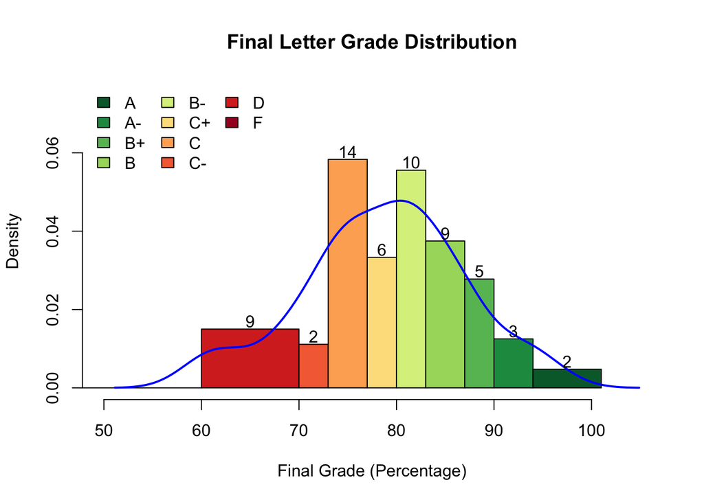

## Histogram (behind the scenes)

```
hist(x, breaks = "Sturges",
     freq = NULL, probability = !freq,
     include.lowest = TRUE, right = TRUE,
     density = NULL, angle = 45, col = NULL,
     border = NULL,
     main = paste("Histogram of" , xname),
     xlim = range(breaks), ylim = NULL,
     xlab = xname, ylab,
     axes = TRUE, plot = TRUE, labels = FALSE,
     nclass = NULL, warn.unused = TRUE, ...)
```

- **`freq`** = show frequencies (`T`) or probabilities (`F`)
- **`xlim`** = x min and max (numeric vector of 2)
- **`ylim`** = y min and max (numeric vector of 2)

## Histogram

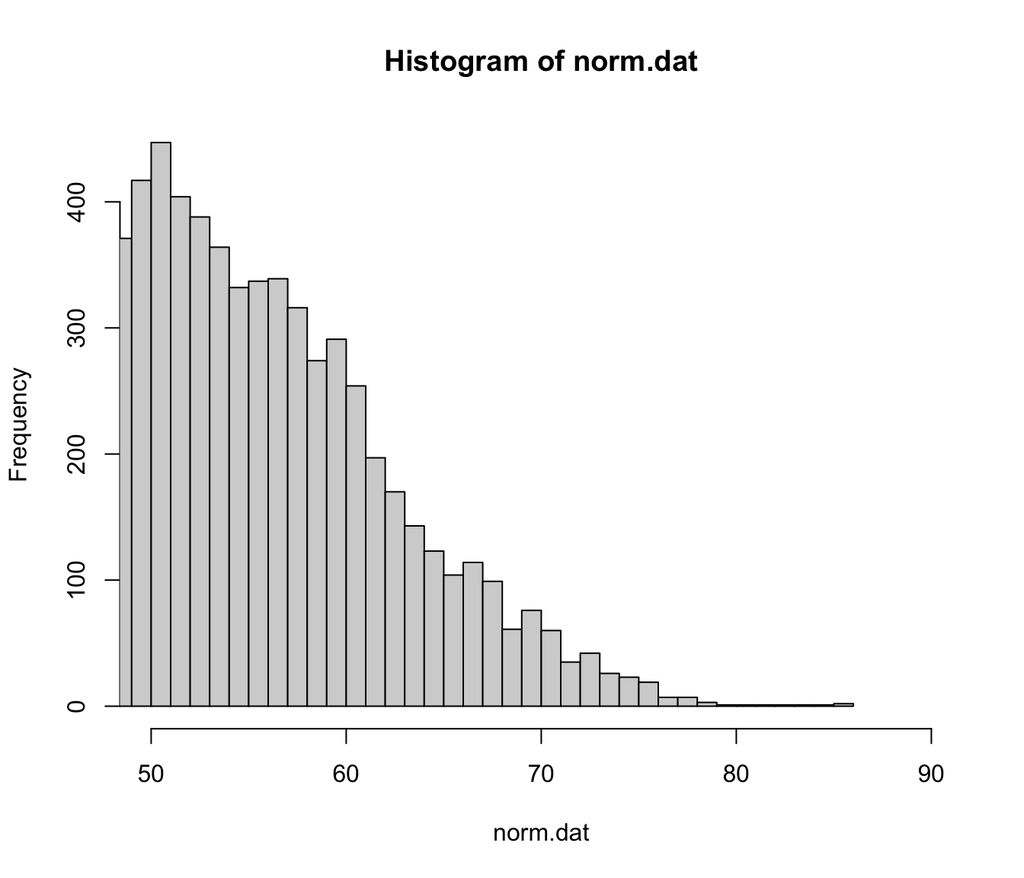

```r
hist(norm.dat, breaks=100, xlim=c(50,90))
```

## Histogram

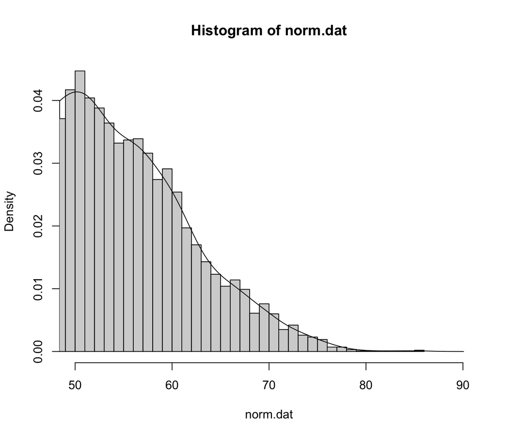

```r
hist(norm.dat, breaks=100, xlim=c(50,90), freq = F) # Must change to freq = F
lines(density(norm.dat)) # see ?density and ?lines
```

## Boxplot

- `boxplot()`
- `par()`

## Boxplot

```r
library(ggplot2)
data(msleep) # ?msleep
str(msleep)
```

```
## tibble [83 × 11] (S3: tbl_df/tbl/data.frame)
##  $ name        : chr [1:83] "Cheetah" "Owl monkey" "Mountain beaver" "Greater short-tailed shrew" ...
##  $ genus       : chr [1:83] "Acinonyx" "Aotus" "Aplodontia" "Blarina" ...
##  $ vore        : chr [1:83] "carni" "omni" "herbi" "omni" ...
##  $ order       : chr [1:83] "Carnivora" "Primates" "Rodentia" "Soricomorpha" ...
##  $ conservation: chr [1:83] "lc" NA "nt" "lc" ...
##  $ sleep_total : num [1:83] 12.1 17 14.4 14.9 4 14.4 8.7 7 10.1 3 ...
##  $ sleep_rem   : num [1:83] NA 1.8 2.4 2.3 0.7 2.2 1.4 NA 2.9 NA ...
##  $ sleep_cycle : num [1:83] NA NA NA 0.133 0.667 ...
##  $ awake       : num [1:83] 11.9 7 9.6 9.1 20 9.6 15.3 17 13.9 21 ...
##  $ brainwt     : num [1:83] NA 0.0155 NA 0.00029 0.423 NA NA NA 0.07 0.0982 ...
##  $ bodywt      : num [1:83] 50 0.48 1.35 0.019 600 ...
```

## Change `vore` to factor

```r
msleep$vore<-factor(msleep$vore)
str(msleep)
```

```
## tibble [83 × 11] (S3: tbl_df/tbl/data.frame)
##  $ name        : chr [1:83] "Cheetah" "Owl monkey" "Mountain beaver" "Greater short-tailed shrew" ...
##  $ genus       : chr [1:83] "Acinonyx" "Aotus" "Aplodontia" "Blarina" ...
##  $ vore        : Factor w/ 4 levels "carni","herbi",..: 1 4 2 4 2 2 1 NA 1 2 ...
##  $ order       : chr [1:83] "Carnivora" "Primates" "Rodentia" "Soricomorpha" ...
##  $ conservation: chr [1:83] "lc" NA "nt" "lc" ...
##  $ sleep_total : num [1:83] 12.1 17 14.4 14.9 4 14.4 8.7 7 10.1 3 ...
##  $ sleep_rem   : num [1:83] NA 1.8 2.4 2.3 0.7 2.2 1.4 NA 2.9 NA ...
##  $ sleep_cycle : num [1:83] NA NA NA 0.133 0.667 ...
##  $ awake       : num [1:83] 11.9 7 9.6 9.1 20 9.6 15.3 17 13.9 21 ...
##  $ brainwt     : num [1:83] NA 0.0155 NA 0.00029 0.423 NA NA NA 0.07 0.0982 ...
##  $ bodywt      : num [1:83] 50 0.48 1.35 0.019 600 ...
```

## Boxplot

Is there a relationship between the total amount of sleep mammals get with what they eat?

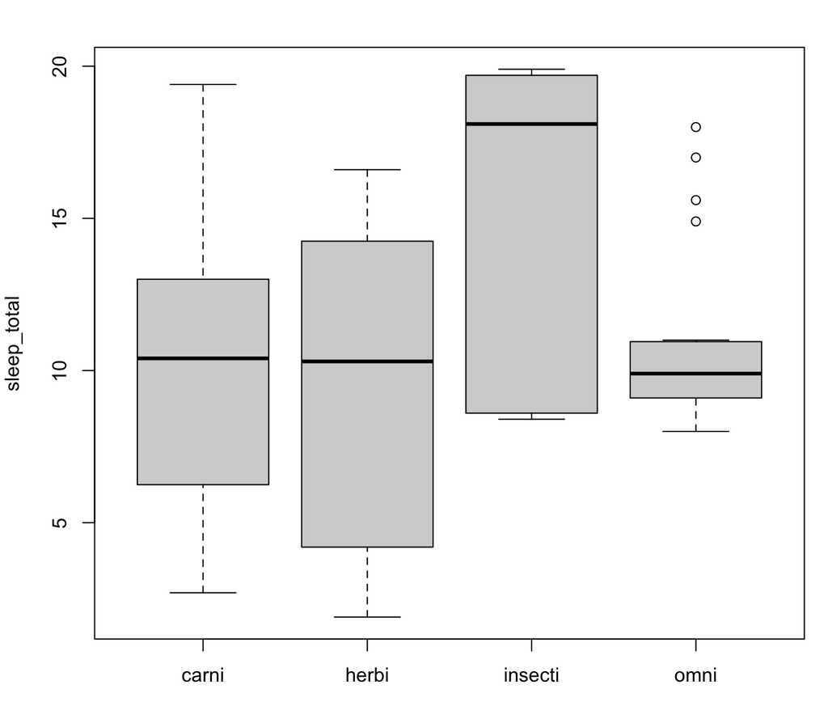

```r
boxplot(sleep_total~vore, msleep)
```

- `~` = “as a function of” or “as modeled by”
  - `y-axis-data ~ x-axis-data`

## Boxplot

Both `hist()` and `boxplot()` return information in addition to the plot.

- Decorate the plot more or provide statistics (median, etc)

```r
bp.data<-boxplot(sleep_total~vore, msleep, plot=F)
str(bp.data)
```

```
## List of 6
##  $ stats: num [1:5, 1:4] 2.7 6.25 10.4 13 19.4 ...
##  $ n    : num [1:4] 19 32 5 20
##  $ conf : num [1:2, 1:4] 7.95 12.85 7.49 13.11 10.26 ...
##  $ out  : num [1:4] 17 14.9 18 15.6
##  $ group: num [1:4] 4 4 4 4
##  $ names: chr [1:4] "carni" "herbi" "insecti" "omni"
```

#`par()`

## `par()`

- Access to all graphical **par**ameters
- The function `par()` returns a special **named list** of values

```r
par()
```

```
## $xlog
## [1] FALSE
##
## $ylog
## [1] FALSE
##
## $adj
## [1] 0.5
##
## $ann
## [1] TRUE
##
## $ask
## [1] FALSE
##
## $bg
## [1] "white"
##
## $bty
## [1] "o"
##
## $cex
## [1] 1
##
## $cex.axis
## [1] 1
##
## $cex.lab
## [1] 1
##
## $cex.main
## [1] 1.2
##
## $cex.sub
## [1] 1
##
## $cin
## [1] 0.15 0.20
##
## $col
```

[output cut: 160 more lines]

```
##
## $xpd
## [1] FALSE
##
## $yaxp
## [1] 0 1 5
##
## $yaxs
## [1] "r"
##
## $yaxt
## [1] "s"
##
## $ylbias
## [1] 0.2
```

## `par()`

- Like a list, you can index it.

```r
par()[1:2]
```

```
## $xlog
## [1] FALSE
##
## $ylog
## [1] FALSE
```

## `par()`

```r
par("fg")
```

```
## [1] "black"
```

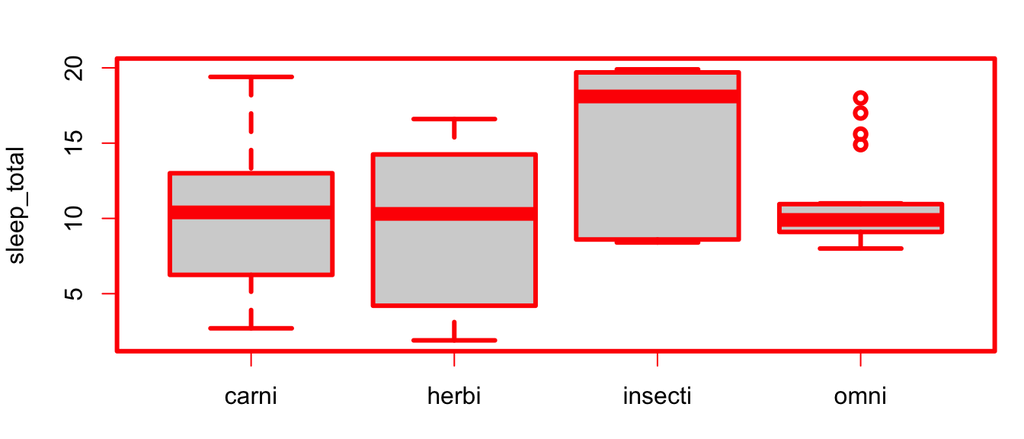

```r
par(fg="red", lwd=3)
boxplot(sleep_total~vore, msleep)
```

## `par()`

```r
par("cex")
```

```
## [1] 1
```

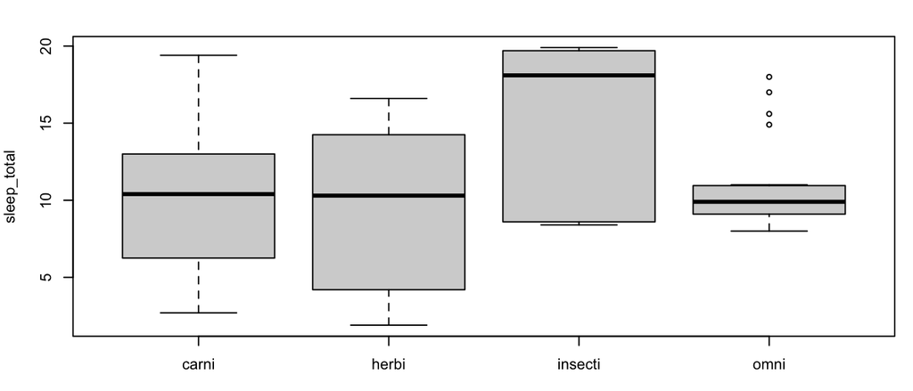

```r
par(cex=0.7)
boxplot(sleep_total~vore, msleep)
```

## `par()`

- `par()` contains 72 parameters

```r
length(par())
```

```
## [1] 72
```

```r
head(names(par()), 50)
```

```
##  [1] "xlog"      "ylog"      "adj"       "ann"       "ask"       "bg"
##  [7] "bty"       "cex"       "cex.axis"  "cex.lab"   "cex.main"  "cex.sub"
## [13] "cin"       "col"       "col.axis"  "col.lab"   "col.main"  "col.sub"
## [19] "cra"       "crt"       "csi"       "cxy"       "din"       "err"
## [25] "family"    "fg"        "fig"       "fin"       "font"      "font.axis"
## [31] "font.lab"  "font.main" "font.sub"  "lab"       "las"       "lend"
## [37] "lheight"   "ljoin"     "lmitre"    "lty"       "lwd"       "mai"
## [43] "mar"       "mex"       "mfcol"     "mfg"       "mfrow"     "mgp"
## [49] "mkh"       "new"
```

## `par()` tips

- If changed in `par()`, will be changed **globally** until reset manually or R session terminated
- Can be specified within plot function to change temporarily (e.g., `plot(y~x, data, col="red")`)
- **OR**, *always use `knitr` and RMarkdown.* `par()` resets every code chunk, *unless* you tell it not to.

## Scatterplots

- `plot()`
- `legend()`

## Scatterplots

- Simply use the generic command `plot()`

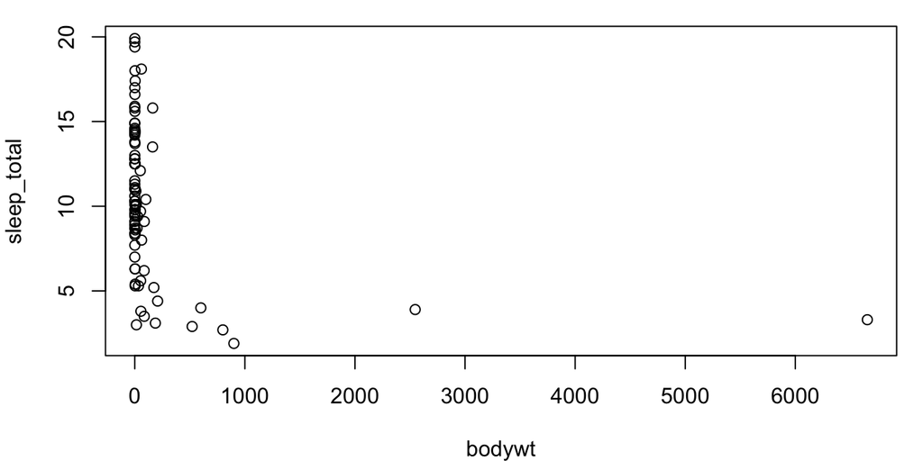

```r
plot(sleep_total~bodywt, msleep)
```

## Scatterplots

- `plot()` knows to make a scatterplot with “numeric ~ numeric” input

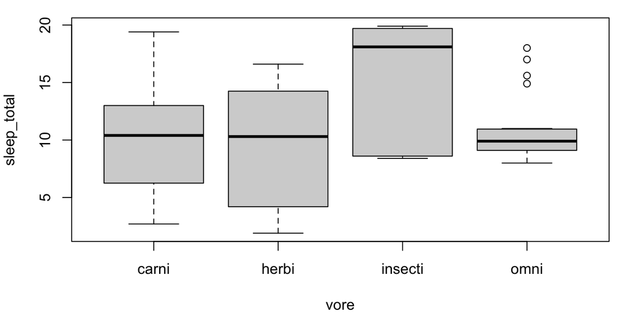

```r
plot(sleep_total~vore, msleep) # Decides it's a job for boxplot
```

## Scatterplots

- Simply use the generic command `plot()`

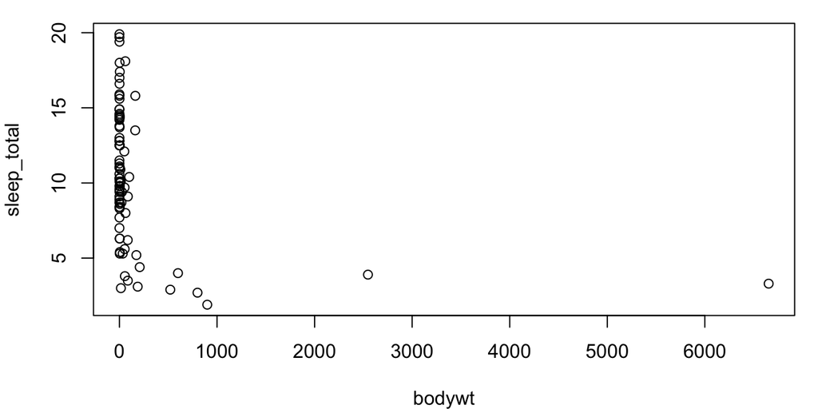

```r
plot(sleep_total~bodywt, msleep)
```

## Scatterplots

- use `log="x"` and `log="y"` to log transform **axis**, not the data
- use `log="xy"` to transform both axes

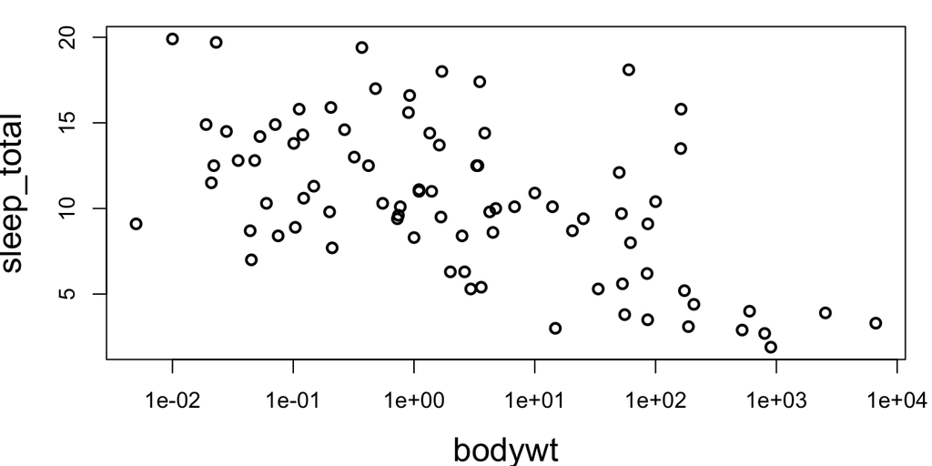

```r
plot(sleep_total~bodywt, msleep, log="x", cex.lab=1.5, lwd=2)
```

#Colors

## Very, very basic R colors

- **Names**: “black”, “red”, “green”, “blue”, “cyan”, “magenta”, “yellow”, “grey” (or “gray”)
- **Number**: 1, 2, 3, 4, 5, 6, 7, 8
- Recycles to infinity
  - i.e., 9 = “black”, 10 = “red”, so on
- Also have “white”
- 0 = “transparent”

## Very, very basic R colors

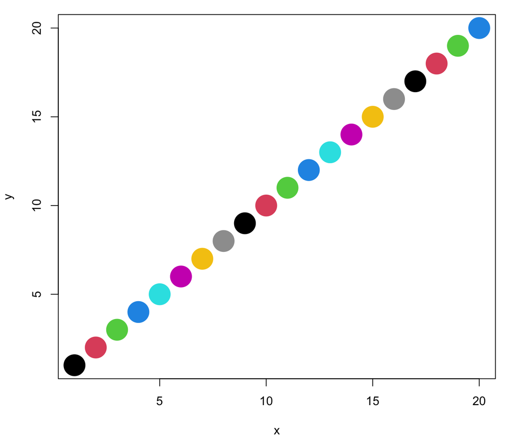

```r
x<-y<-1:20 # Yes, you can do this
plot(y~x, col=x, pch=16, cex=4)
```

## Scatterplots: Add a Legend based on `vore`

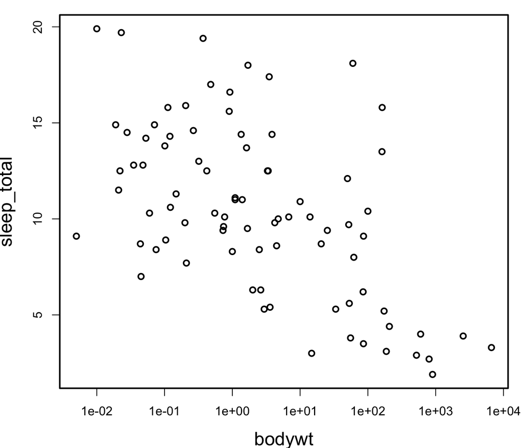

```r
plot(sleep_total~bodywt, msleep, log="x")
```

## Scatterplots: Add a Legend based on `vore`

```r
head(msleep$vore, 10)
```

```
##  [1] carni omni  herbi omni  herbi herbi carni <NA>  carni herbi
## Levels: carni herbi insecti omni
```

```r
head(as.integer(msleep$vore), 10)
```

```
##  [1]  1  4  2  4  2  2  1 NA  1  2
```

```r
levels(msleep$vore)
```

```
## [1] "carni"   "herbi"   "insecti" "omni"
```

## Scatterplots: Add a Legend based on `vore`

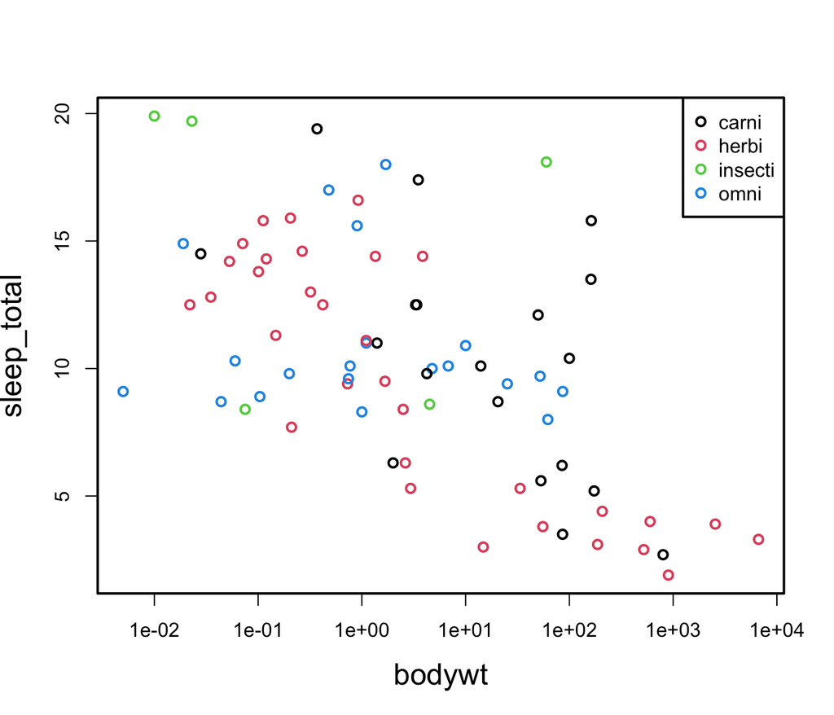

```r
plot(sleep_total~bodywt, msleep, log="x", col=msleep$vore)
legend("topright", legend=levels(msleep$vore), col=1:4, pch=1)
```

## Plotting Exercise

1.Using the `rhone` dataset in the `ade4` package, plot a variable of your choice as a function of `air.temp`. Add plain english axis labels and a title for the plot.

2.Increase the expansion factor by 50% and remove the box around the plot.

3.Change data symbols from small circles to triangles.

## Plotting Exercise

1.Using the `rhone` dataset in the `ade4` package, plot a variable of your choice as a function of `air.temp`. Add plain english axis labels and a title for the plot.

```r
library(ade4)
data(rhone)
str(rhone)
```

```
## List of 3
##  $ tab  :'data.frame':   39 obs. of  15 variables:
##   ..$ air.temp  : num [1:39] 2 2 10 16 15 10 15 12 16 23 ...
##   ..$ wat.temp  : num [1:39] 5.9 3.4 7.5 9.1 9.6 10.1 11.4 9.5 11 16.3 ...
##   ..$ conduc    : num [1:39] 359 348 260 298 287 277 293 295 299 243 ...
##   ..$ pH        : num [1:39] 8.2 7.9 8 7.9 8.2 8.2 8.2 8.1 8.3 8.1 ...
##   ..$ oxygen    : num [1:39] 93 92 94 101 96 98 98 98 95 93 ...
##   ..$ secchi    : num [1:39] 67 203 176 85 40 28 22 55 22 73 ...
##   ..$ caco3     : num [1:39] 186 176 176 165 167 165 176 170 170 135 ...
##   ..$ totca     : num [1:39] 62.9 57.7 60.1 57.7 58.9 57.3 62.1 58.9 60.1 45.3 ...
##   ..$ mg        : num [1:39] 7.1 7.8 6.3 5.1 4.9 5.3 5.1 5.6 4.9 5.3 ...
##   ..$ so4       : num [1:39] 35 42.1 32.9 32.8 24.4 28.6 22.5 29.8 30.7 33.5 ...
##   ..$ no2       : num [1:39] 0.55 0.78 0.54 0.63 0.48 0.48 0.55 0.5 0.65 0.54 ...
##   ..$ hco3      : num [1:39] 177 159 170 161 177 ...
##   ..$ suspension: num [1:39] 17.3 3.7 4.4 22 44.9 92.4 98 40 29.3 26.6 ...
##   ..$ organique : num [1:39] 2.6 0.9 1.2 3.7 5.6 8.8 9.8 4.4 4.4 5.4 ...
##   ..$ chloro    : num [1:39] 1.4 1.6 5.7 6.2 2.9 9.2 4.4 10.6 1.5 6.4 ...
##  $ date : num [1:39] 33 53 73 109 123 129 138 144 151 158 ...
##  $ disch:'data.frame':   39 obs. of  3 variables:
##   ..$ Geneva: num [1:39] 299 266 113 389 315 254 357 469 435 351 ...
##   ..$ Arve  : num [1:39] 60 30.7 53 99.5 141 312 197 117 119 193 ...
##   ..$ Others: num [1:39] 218 89.3 255 248.5 433 ...
```

## Plotting Exercise

1.Using the `rhone` dataset in the `ade4` package, plot a variable of your choice as a function of `air.temp`. Add plain english axis labels and a title for the plot.

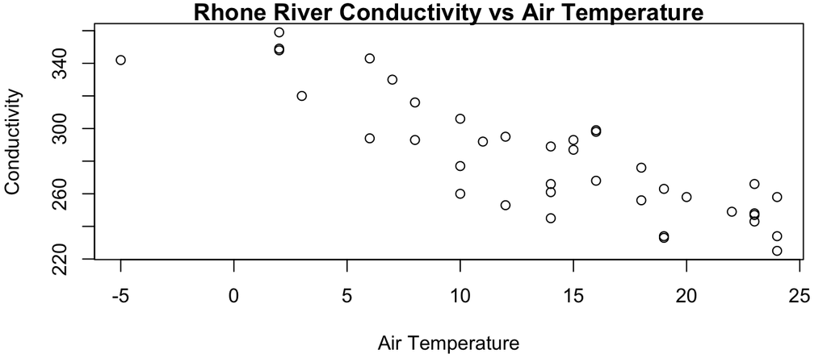

```r
rh<-rhone$tab
plot(conduc~air.temp, rh, xlab="Air Temperature",
     ylab="Conductivity",
     main="Rhone River Conductivity vs Air Temperature")
```

## Plotting Exercise

2.Increase the size of everything by 50% (a.k.a. expansion factor), double the line thickness of the symbols, and remove the box around the plot.

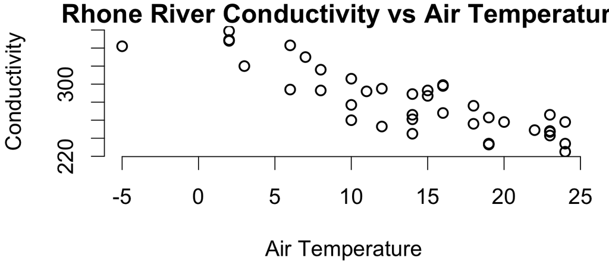

```r
par(cex=1.5, lwd=2, bty="n")
plot(conduc~air.temp, rh, xlab="Air Temperature",
     ylab="Conductivity",
     main="Rhone River Conductivity vs Air Temperature")
```

## Plotting Exercise

3.Change data symbols from small circles to triangles.

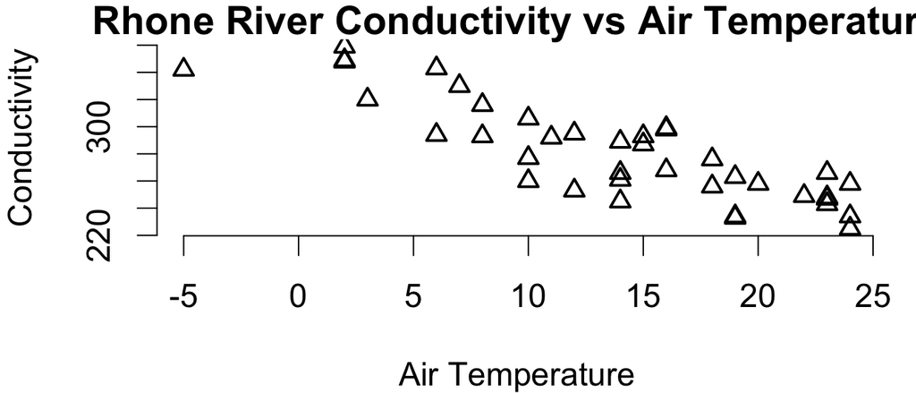

```r
par(cex=1.5, lwd=2, bty="n", pch=2)
plot(conduc~air.temp, rh, xlab="Air Temperature",
     ylab="Conductivity",
     main="Rhone River Conductivity vs Air Temperature")
```